# Dados sobre séries de TV

Analisaremos os episódios das séries Black Mirror, Breaking Bad e Orphan Black.

```r
episodes = read_csv(here("data/series_from_imdb.csv"),
                    progress = FALSE,
                    col_types = cols(.default = col_double(),
                                     series_name = col_character(),
                                     episode = col_character(),
                                     url = col_character(),
                                     season = col_character())) %>%
    filter(series_name %in% c("Orphan Black", "Black Mirror", "Breaking Bad"))
```

### Qual das séries que você escolheu é mais bem avaliada no IMDB? A diferença é grande? Pequena? Muda de acordo com as temporadas da série?

Para responder essas perguntas precisaremos analisar a avaliação feita pelos usuários para os episódios de cada série. Nesse gráfico são utilizadas as medianas das avaliações das temporadas.

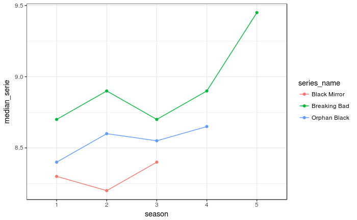

```r
data_median <- episodes %>%
    group_by(series_name, season) %>%
    summarise(median_serie = median(user_rating))

ggplot(data = data_median,  aes(x = season, y = median_serie, color = series_name, group=series_name)) +
geom_line(stat='identity') +
     geom_point()
```

Através desse gráfico é possível perceber que a série mais bem avaliada no IMDB é Breaking Bad. Para verificar se a diferença entre as outras é grande, iremos calcular a média dos pontos obtidos através do gráfico:

```r
data_median %>%
    group_by(series_name) %>%
    summarise(media = mean(median_serie))
```

| series_name | media |
| --- | --- |
| Black Mirror | 8.30 |
| Breaking Bad | 8.93 |
| Orphan Black | 8.55 |

Dessa forma, concluímos que não há uma diferença muito grande com relação às outras séries. Além disso, observamos que os pontos do gráfico não seguem um padrão contínuo, ou seja, as avaliações estão variando de acordo com as temporadas.

### Qual das séries que você escolheu tem episódios de qualidade mais irregular segundo o IMDB? A diferença é grande? Pequena?

Para obter essa resposta, vamos calcular o desvio padrão das medianas encontradas no gráfico anterior.  
- **Black Mirror**:

```r
medians_BM <- data_median %>%
    filter(series_name %in% c("Black Mirror"))
med_BM = medians_BM$median_serie
sd(med_BM)
```

```
[1] 0.1
```

- **Breaking Bad**:

```r
medians_BB <- data_median %>%
    filter(series_name %in% c("Breaking Bad"))
med_BB = medians_BB$median_serie
sd(med_BB)
```

```
[1] 0.3074085
```

- **Orphan Black**:

```r
medians_OB <- data_median %>%
    filter(series_name %in% c("Orphan Black"))
med_OB = medians_OB$median_serie
sd(med_OB)
```

```
[1] 0.1080123
```

Ou seja, Breaking Bad possui mais episódios de qualidade mais irregular segundo o IMDB, pois um alto desvio padrão indica que os pontos dos dados estão espalhados por uma ampla gama de valores. A diferença dessa entre as outras duas é grande, mas das outras duas entre si é pequena.

### Qual das séries ou temporadas tem episódios mais sem graça? (Um episódio é sem graça se ninguém nem ama nem odeia ele)

Os boxplots contruídos para encontrar essa resposta foi montado com base no somatório da proporção de usuários que avaliaram o episódio com os valores 4, 5 ou 6. Nesse caso, estamos avaliando todos os episódios de cada série, então iremos descobrir qual das séries tem episódios mais sem graça.

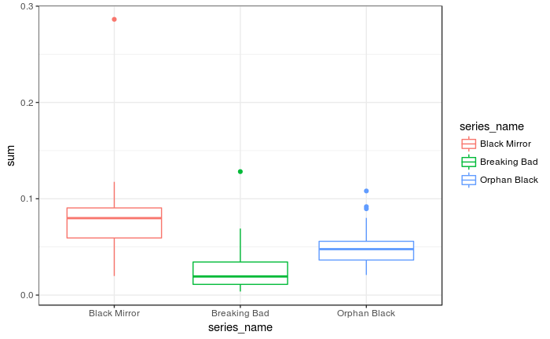

```r
data_not_funny <- episodes %>%
    group_by(series_name, episode) %>%
    summarise(sum = r4+r5+r6)
ggplot(data = data_not_funny,  aes(x = series_name, y = sum, color = series_name, group=series_name)) +
geom_boxplot()
```

Pela distribuição dos dados mostrados nos boxplots, obtemos o seguinte ranking de séries que tem episódios mais sem graça:  
**1º Black Mirror**  
**2º Orphan Black**  
**3º Breaking Bad**  
Essa conclusão é feita com base na linha da mediana de cada boxplot, dessa forma, a proporção de usuários que avaliaram os episódios de Black Mirror com os valores 4, 5 ou 6 é a maior dentre as 3 séries.

### Episódios no início/fim da temporada são mais bem avaliados que os no meio? O que tende a ser melhor? Inícios ou finais de séries/temporadas?

**- Black Mirror**

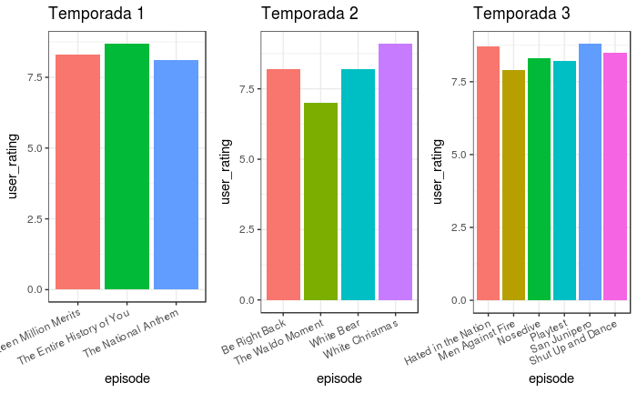

```r
season1BM = episodes %>%
    filter(series_name %in% c("Black Mirror")) %>%
    filter(season == 1)
season2BM = episodes %>%
    filter(series_name %in% c("Black Mirror")) %>%
    filter(season == 2)
season3BM = episodes %>%
    filter(series_name %in% c("Black Mirror")) %>%
    filter(season == 3)
g1BM <- ggplot(data = season1BM, mapping = aes(x = episode, y = user_rating, fill = episode))+
    geom_bar(stat = 'identity') +
    ggtitle("Temporada 1") +
    theme(axis.text.x = element_text(angle = 25, hjust = 1), legend.position="none")
g2BM <- ggplot(data = season2BM, mapping = aes(x = episode, y = user_rating, fill= episode))+
    geom_bar(stat = 'identity') +
    ggtitle("Temporada 2") +
    theme(axis.text.x = element_text(angle = 25, hjust = 1), legend.position="none")
g3BM <- ggplot(data = season3BM, mapping = aes(x = episode, y = user_rating, fill = episode))+
    geom_bar(stat = 'identity') +
    ggtitle("Temporada 3") +
    theme(axis.text.x = element_text(angle = 25, hjust = 1), legend.position="none")
grid.arrange(g1BM, g2BM, g3BM, nrow = 1)
```

No caso de Black Mirror, não há o padrão de que os episódios são melhores avaliadas no início ou no fim da temporada, acredito que isso ocorra porque os episódios são independentes *(apesar de o último episódio ser o mais bem avaliado na segunda temporada, não se torna padrão, porque essa fato não é repetido para as outras temporadas)*.

**- Breaking Bad**

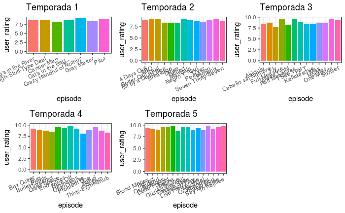

```r
season1BB = episodes %>%
    filter(series_name %in% c("Breaking Bad")) %>%
    filter(season == 1)
season2BB = episodes %>%
    filter(series_name %in% c("Breaking Bad")) %>%
    filter(season == 2)
season3BB = episodes %>%
    filter(series_name %in% c("Breaking Bad")) %>%
    filter(season == 3)
season4BB = episodes %>%
    filter(series_name %in% c("Breaking Bad")) %>%
    filter(season == 4)
season5BB = episodes %>%
    filter(series_name %in% c("Breaking Bad")) %>%
    filter(season == 5)
g1BB <- ggplot(data = season1BB, mapping = aes(x = episode, y = user_rating, fill = episode))+
    geom_bar(stat = 'identity') +
    ggtitle("Temporada 1") +
    theme(axis.text.x = element_text(angle = 25, hjust = 1), legend.position="none")
g2BB <- ggplot(data = season2BB, mapping = aes(x = episode, y = user_rating, fill= episode))+
    geom_bar(stat = 'identity') +
    ggtitle("Temporada 2") +
    theme(axis.text.x = element_text(angle = 25, hjust = 1), legend.position="none")
g3BB <- ggplot(data = season3BB, mapping = aes(x = episode, y = user_rating, fill = episode))+
    geom_bar(stat = 'identity') +
    ggtitle("Temporada 3") +
    theme(axis.text.x = element_text(angle = 25, hjust = 1), legend.position="none")
g4BB <- ggplot(data = season4BB, mapping = aes(x = episode, y = user_rating, fill = episode))+
    geom_bar(stat = 'identity') +
    ggtitle("Temporada 4") +
    theme(axis.text.x = element_text(angle = 25, hjust = 1), legend.position="none")
g5BB <- ggplot(data = season5BB, mapping = aes(x = episode, y = user_rating, fill = episode))+
    geom_bar(stat = 'identity') +
    ggtitle("Temporada 5") +
    theme(axis.text.x = element_text(angle = 25, hjust = 1), legend.position="none")
grid.arrange(g1BB, g2BB, g3BB, g4BB, g5BB, nrow = 2)
```

De acordo com os gráficos acima, Breaking Bad também não segue esse padrão, as avaliações variam igualmente ao longo da temporada.

**- Orphan Black**

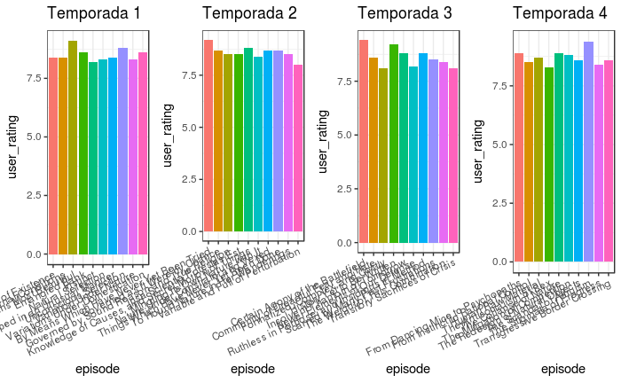

```r
season1OB = episodes %>%
    filter(series_name %in% c("Orphan Black")) %>%
    filter(season == 1)
season2OB = episodes %>%
    filter(series_name %in% c("Orphan Black")) %>%
    filter(season == 2)
season3OB = episodes %>%
    filter(series_name %in% c("Orphan Black")) %>%
    filter(season == 3)
season4OB = episodes %>%
    filter(series_name %in% c("Orphan Black")) %>%
    filter(season == 4)
g1OB <- ggplot(data = season1OB, mapping = aes(x = episode, y = user_rating, fill = episode))+
    geom_bar(stat = 'identity') +
    ggtitle("Temporada 1") +
    theme(axis.text.x = element_text(angle = 25, hjust = 1), legend.position="none")
g2OB <- ggplot(data = season2OB, mapping = aes(x = episode, y = user_rating, fill= episode))+
    geom_bar(stat = 'identity') +
    ggtitle("Temporada 2") +
    theme(axis.text.x = element_text(angle = 25, hjust = 1), legend.position="none")
g3OB <- ggplot(data = season3OB, mapping = aes(x = episode, y = user_rating, fill = episode))+
    geom_bar(stat = 'identity') +
    ggtitle("Temporada 3") +
    theme(axis.text.x = element_text(angle = 25, hjust = 1), legend.position="none")
g4OB <- ggplot(data = season4OB, mapping = aes(x = episode, y = user_rating, fill = episode))+
    geom_bar(stat = 'identity') +
    ggtitle("Temporada 4") +
    theme(axis.text.x = element_text(angle = 25, hjust = 1), legend.position="none")
grid.arrange(g1OB, g2OB, g3OB, g4OB, nrow = 1)
```

Já no caso de Orphan Black, os primeiros episódios das temporadas 2 e 3 obtiveram avaliações melhores, apesar de alguns no meio também obterem avaliações boas.  
Portanto, não podemos concluir se o que tende a ser melhor nas temporadas são inícios ou finais.